# Prediction of patient with liver desease

## About Gender-based differences in performance

One of the research questions was the possibility that, biochemical markers used in this dataset, are useful to predict the disease in Male Patients but are not as good for Female Patients. Here we try to take the results of the best model (Logistic Regression with class weights) and check the predictions with respect to the **Gender** variable.

```python
checker = y_test.copy(deep=True)
```

```python
checker["check"] = result.tolist()
```

```python
checker["Gender"] = ds.loc[checker.index, "Gender"]
```

```
About Males
                       precision    recall  f1-score   support

Without Liver Disease       0.52      0.52      0.52        31
   With Liver Disease       0.81      0.81      0.81        78

             accuracy                           0.72       109
            macro avg       0.66      0.66      0.66       109
         weighted avg       0.72      0.72      0.72       109
```

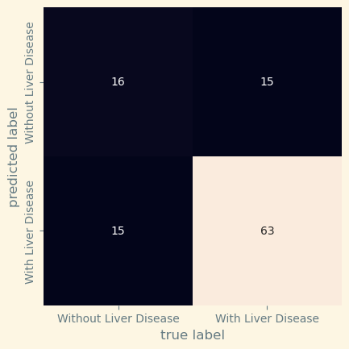

```python
print("About Males")

test = checker[checker["Gender"]==1]["Selector"]
prediction = checker[checker["Gender"]==1]["check"]
print(classification_report(test, prediction, target_names=["Without Liver Disease", "With Liver Disease"]))

mat = confusion_matrix(test, prediction)
sns.heatmap(mat.T, square=True, annot=True, fmt='d', cbar=False,
            xticklabels=["Without Liver Disease", "With Liver Disease"],
            yticklabels=["Without Liver Disease", "With Liver Disease"])

plt.xlabel('true label')
plt.ylabel('predicted label')
```

```
About Females
                       precision    recall  f1-score   support

Without Liver Disease       0.44      0.80      0.57        10
   With Liver Disease       0.87      0.57      0.68        23

             accuracy                           0.64        33
            macro avg       0.66      0.68      0.63        33
         weighted avg       0.74      0.64      0.65        33
```

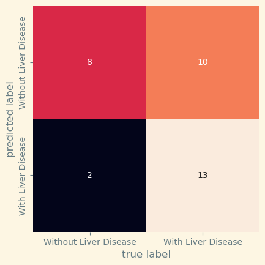

```python
print("About Females")

test = checker[checker["Gender"]==0]["Selector"]
prediction = checker[checker["Gender"]==0]["check"]
print(classification_report(test, prediction, target_names=["Without Liver Disease", "With Liver Disease"]))

mat = confusion_matrix(test, prediction)
sns.heatmap(mat.T, square=True, annot=True, fmt='d', cbar=False,
            xticklabels=["Without Liver Disease", "With Liver Disease"],
            yticklabels=["Without Liver Disease", "With Liver Disease"])

plt.xlabel('true label')
plt.ylabel('predicted label')
```

If we take into consideration Accuracy and F1-score, the model performs better on Male records. So the hypothesis of the research question might be true. However, to fully investigate such question and being able to reach meaningful results, more data is needed. Here we used the same model trained on both Gender. Plus, aside from an imbalance in data wrt **Selector** variable, there is a strong imbalance also wrt **Gender** (Males are roughly three times Females). A single model should be build for each **Gender**, using the same biochemical markers. Maybe, only at that point we would have answers that can address this hypotetical difference.